# Febre de chikungunya no Brasil, 2023 a 2025

Relatório epidemiológico reprodutível · SINAN arboviroses

Autor

Exemplo do curso · MedTrop 2026

Data de Publicação

16 de agosto de 2026

## Preparação do ambiente

Este bloco carrega os pacotes e a paleta do curso. Ele roda na renderização.

**Código**

```r
library(dplyr)
library(tidyr)
library(tibble)
library(ggplot2)

# Carrega a paleta EPIC95 do projeto, se o arquivo existir.
# Caso contrario, define as cores aqui mesmo, para o documento sempre renderizar.
paleta <- here::here("recursos", "epic95_paleta.R")
if (file.exists(paleta)) {
  source(paleta)
} else {
  epic95_cores <- c(primaria = "#4f8aac", secundaria = "#03658c",
                    destaque = "#02735e", neutra = "#ffde59")
  epic95_estendida <- c("#4f8aac", "#03658c", "#02735e", "#ffde59",
                        "#7ba8c0", "#3581a8", "#048972", "#ffe887")
  scale_fill_epic95  <- function(...) ggplot2::scale_fill_manual(values = epic95_estendida, ...)
  scale_color_epic95 <- function(...) ggplot2::scale_color_manual(values = epic95_estendida, ...)
  tema_epic95 <- function(base_size = 12) ggplot2::theme_minimal(base_size = base_size)
}
```

# 1 Introdução

A febre de chikungunya é uma arbovirose causada pelo vírus CHIKV e transmitida ao ser humano pela picada de fêmeas infectadas de *Aedes aegypti*, o mesmo vetor da dengue e do zika. O quadro clínico costuma cursar com febre alta de início súbito e poliartralgia intensa, muitas vezes incapacitante, com dor articular que pode persistir por meses na fase crônica. No Brasil, a doença é de notificação compulsória e seus casos alimentam o Sistema de Informação de Agravos de Notificação (SINAN), no conjunto das arboviroses. A transmissão acompanha a dinâmica do vetor e concentra-se nos meses mais quentes e chuvosos, quando a densidade de *Aedes* aumenta.

Este relatório descreve os casos de chikungunya notificados no Brasil entre 2023 e 2025, a partir dos dados do SINAN, e compara a incidência entre as regiões do país. O objetivo é caracterizar os casos por pessoa, tempo e lugar, estimar a taxa de incidência por região e quantificar a diferença entre regiões com um modelo de regressão de Poisson.

# 2 Métodos

## 2.1 Fonte dos dados

Os dados provêm do Sistema de Informação de Agravos de Notificação (SINAN), no conjunto de arboviroses referente à febre de chikungunya, nos anos de 2023 a 2025. A fonte primária é o Portal de Dados Abertos do SUS (OpenDataSUS). A extração e a preparação seguem o script `R/00_preparar_dados.R` do projeto, que baixa os arquivos por ano, seleciona as colunas de interesse didático, decodifica os campos, remove dados que identifiquem o paciente e grava o arquivo único `dados/chikungunya_2023_2025.csv`, que este relatório lê. Cada registro corresponde a uma notificação, com as variáveis: data de notificação (`dt_notificacao`), ano, região, sexo, idade, faixa etária, classificação final (`classificacao`), critério de confirmação e evolução.

O bloco abaixo carrega esse arquivo.

**Código**

```r
library(readr)
library(dplyr)
library(tibble)

# Em aula, este arquivo e o dado real do SINAN preparado pelo 00_preparar_dados.R.
# A base sintetica abaixo e so uma rede de seguranca, com as MESMAS colunas.
caminho <- here::here("dados", "chikungunya_2023_2025.csv")

if (file.exists(caminho)) {
  chik <- read_csv(caminho, show_col_types = FALSE)
} else {
  set.seed(95)
  n <- 4000
  datas <- as.Date("2023-01-01") + sample(0:1095, n, replace = TRUE,
            prob = rep(c(3, 3, 2, 1), length.out = 1096))
  chik <- tibble(
    dt_notificacao = datas,
    ano = as.integer(format(datas, "%Y")),
    regiao = sample(c("Sudeste", "Nordeste", "Centro-Oeste"), n,
      replace = TRUE, prob = c(5, 4, 2)),
    classificacao = sample(
      c("Chikungunya confirmada", "Descartado", "Outro/ignorado"), n,
      replace = TRUE, prob = c(6, 3, 1))
  )
}
```

## 2.2 Limpeza e organização

O tratamento converte `dt_notificacao` para formato de data, deriva o ano a partir dela, decodifica a idade e a faixa etária do padrão do SINAN, padroniza a classificação final em “Chikungunya confirmada” e “Descartado” e exclui os registros sem data de notificação. Todo esse processamento vive no `R/00_preparar_dados.R`, de modo que o objeto `chik` já chega limpo ao relatório. O bloco abaixo apenas confirma o formato do dado recebido.

**Código**

```r
glimpse(chik)
```

```
Rows: 49,951
Columns: 12
$ dt_notificacao <date> 2023-01-08, 2023-01-09, 2023-01-09, 2023-01-10, 2023-0…
$ ano            <dbl> 2023, 2023, 2023, 2023, 2023, 2023, 2023, 2023, 2023, 2…
$ semana_epi     <chr> "02", "02", "02", "02", "02", "02", "02", "02", "03", "…
$ uf             <dbl> 32, 32, 32, 32, 32, 32, 32, 32, 32, 32, 32, 32, 32, 32,…
$ municipio_ibge <dbl> 320530, 320510, 320360, 320280, 320530, 320130, 320332,…
$ regiao         <chr> "Sudeste", "Sudeste", "Sudeste", "Sudeste", "Sudeste", …
$ sexo           <chr> "Masculino", "Masculino", "Feminino", "Feminino", "Femi…
$ idade          <dbl> 35, 8, 65, 47, 49, 19, 25, 55, 41, 46, 71, 39, 30, 15, …
$ faixa_etaria   <chr> "20-39", "5-9", "60+", "40-59", "40-59", "10-19", "20-3…
$ classificacao  <chr> "Chikungunya confirmada", "Chikungunya confirmada", "De…
$ criterio       <chr> "Clinico-epidemiologico", "Clinico-epidemiologico", "La…
$ evolucao       <chr> "Cura", "Cura", "Ignorado", "Ignorado", "Cura", "Ignora…
```

## 2.3 Indicadores e análise

Foi calculada a taxa de incidência de chikungunya confirmada por 100 mil habitantes, por região, tomando os casos confirmados como numerador e a população regional como denominador. Para comparar as regiões, ajustou-se um modelo de regressão de Poisson ao número de casos, com o logaritmo da população como *offset*, o que faz o modelo estimar razões de taxas de incidência e não contagens brutas. O Nordeste foi definido como categoria de referência. O indicador e o modelo usam apenas os anos fechados de 2023 e 2024. Por fim, a série mensal de casos por data de notificação foi examinada quanto a tendência e sazonalidade, com a ressalva de que 2025 vem incompleto por atraso de notificação. A preparação dos dados que sustenta essas análises está em `R/00_preparar_dados.R`.

# 3 Resultados

## 3.1 Descrição dos casos

No período de 2023 a 2025, a base reúne 49951 notificações de chikungunya, das quais 25051 foram classificadas como confirmadas. As notificações abrangem as diferentes regiões do país e distribuem-se ao longo dos três anos por data de notificação. A base registra sexo, idade e faixa etária de cada caso, o que permite a caracterização por pessoa; por tempo, a data de notificação; e por lugar, a região de residência. A distribuição por região aparece agregada nas seções seguintes, e a distribuição temporal, na série mensal ao fim dos Resultados.

A Tabela 1 abre a caracterização pela pessoa, a primeira pergunta da tríade descritiva. Ela resume sexo, idade, faixa etária e evolução, e quebra o quadro entre mulheres e homens. Não testa hipótese: retrata quem está no dado, que é como todo boletim e todo artigo começam.

**Código**

```r
library(gtsummary)
# So monta a Tabela 1 se as colunas de pessoa existirem. A rede de seguranca
# sintetica dos Metodos nao as tem, entao o relatorio segue sem a tabela.
tem_pessoa <- all(c("sexo", "idade", "faixa_etaria", "evolucao") %in% names(chik))
```

**Código**

```r
chik |>
  mutate(sexo = na_if(sexo, "Ignorado")) |>   # "Ignorado" e ausencia, nao categoria
  filter(!is.na(sexo)) |>
  select(sexo, idade, faixa_etaria, classificacao, evolucao) |>
  tbl_summary(
    by = sexo,
    label = list(
      idade         ~ "Idade (anos)",
      faixa_etaria  ~ "Faixa etária",
      classificacao ~ "Classificação do caso",
      evolucao      ~ "Evolução"
    )
  ) |>
  add_overall() |>
  modify_header(label ~ "**Característica**")
```

Tabela 1: Caracterização dos casos notificados de chikungunya, no total e por sexo (2023-2025).

| **Característica** | **Overall** N = 49,899<sup>1</sup> | **Feminino** N = 29,445<sup>1</sup> | **Masculino** N = 20,454<sup>1</sup> |
| --- | --- | --- | --- |
| Idade (anos) | 37 (22, 52) | 39 (24, 53) | 34 (19, 51) |
| Unknown | 1 | 1 | 0 |
| Faixa etária |  |  |  |
| <1 | 507 (1.0%) | 261 (0.9%) | 246 (1.2%) |
| 1-4 | 1,213 (2.4%) | 585 (2.0%) | 628 (3.1%) |
| 10-19 | 6,267 (13%) | 3,172 (11%) | 3,095 (15%) |
| 20-39 | 16,765 (34%) | 9,880 (34%) | 6,885 (34%) |
| 40-59 | 14,941 (30%) | 9,574 (33%) | 5,367 (26%) |
| 5-9 | 2,201 (4.4%) | 1,035 (3.5%) | 1,166 (5.7%) |
| 60+ | 8,004 (16%) | 4,937 (17%) | 3,067 (15%) |
| Unknown | 1 | 1 | 0 |
| Classificação do caso |  |  |  |
| Chikungunya confirmada | 25,027 (50%) | 15,137 (51%) | 9,890 (48%) |
| Descartado | 20,769 (42%) | 11,935 (41%) | 8,834 (43%) |
| Outro/ignorado | 4,103 (8.2%) | 2,373 (8.1%) | 1,730 (8.5%) |
| Evolução |  |  |  |
| Cura | 40,000 (80%) | 23,777 (81%) | 16,223 (79%) |
| Ignorado | 9,777 (20%) | 5,612 (19%) | 4,165 (20%) |
| Obito pelo agravo | 31 (<0.1%) | 16 (<0.1%) | 15 (<0.1%) |
| Obito por outra causa | 91 (0.2%) | 40 (0.1%) | 51 (0.2%) |

<sup>1</sup> Median (Q1, Q3); n (%)

A leitura por pessoa costuma mostrar concentração em adultos, com discreto predomínio feminino, o padrão esperado da chikungunya pela exposição ao vetor e pela busca de atendimento. A coluna de evolução, com a maioria de curas, e a linha de classificação preparam a próxima leitura: a positividade por região.

A Figura 1 mostra a classificação final dentro de cada região, em proporção. Com as barras somando 100%, o que se compara é a fatia de confirmados, e não o total de notificações. Onde essa fatia é maior, a positividade é mais alta, o que pode refletir circulação mais intensa do vírus ou maior acesso ao diagnóstico. A figura levanta a pergunta; a investigação decide qual explicação vale.

**Código**

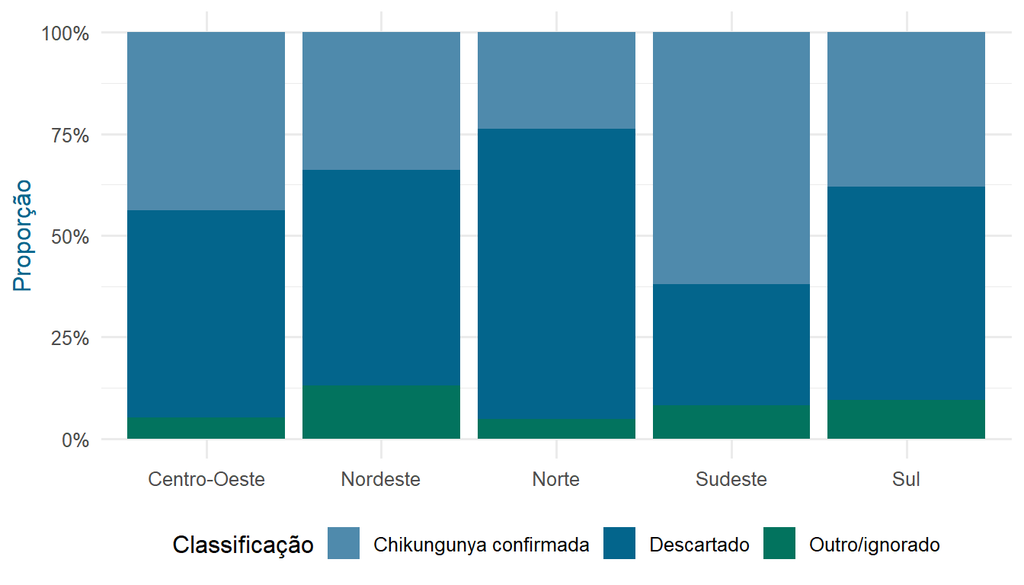

Figura 1: Classificação final do caso de chikungunya por região, em proporção dentro de cada região (2023-2025).

```r
ggplot(chik, aes(x = regiao, fill = classificacao)) +
  geom_bar(position = "fill") +
  scale_y_continuous(labels = scales::percent) +
  scale_fill_epic95() +
  labs(x = NULL, y = "Proporção", fill = "Classificação") +
  tema_epic95()
```

Os blocos abaixo partem do `chik` carregado nos Métodos. Para o indicador e o modelo, agregamos os casos confirmados por região, nos anos fechados de 2023 e 2024, e juntamos a uma população por região (IBGE, ilustrativa). O ano de 2025 fica de fora do indicador e do modelo por vir incompleto; ele reaparece na série mensal logo adiante, justamente para mostrar o efeito do atraso.

**Agregação por região (casos confirmados, 2023-2024)**

```r
library(lubridate)

# Populacao por regiao (IBGE, ilustrativa). Em aula, use a estimativa oficial.
populacao_regiao <- tribble(
  ~regiao,         ~populacao,
  "Norte",          18900000,
  "Nordeste",       57700000,
  "Sudeste",        89600000,
  "Sul",            30400000,
  "Centro-Oeste",   16700000
)

# Uma linha por regiao e ano: e este formato que a regressao usa (mais de uma
# observacao por regiao deixa graus de liberdade para o modelo).
casos_regiao_ano <- chik |>
  filter(classificacao == "Chikungunya confirmada", ano %in% 2023:2024) |>
  count(regiao, ano, name = "casos") |>
  inner_join(populacao_regiao, by = "regiao")

# Versao agregada por regiao (somando os dois anos), para a tabela e a figura.
tab <- casos_regiao_ano |>
  group_by(regiao) |>
  summarise(casos = sum(casos), populacao = first(populacao), .groups = "drop") |>
  mutate(
    incidencia = round(casos / populacao * 1e5, 1)  # por 100 mil habitantes
  ) |>
  arrange(desc(incidencia))
```

## 3.2 Taxa de incidência por região

A Tabela 2 traz a taxa de incidência de chikungunya confirmada por 100 mil habitantes, por região.

**Código**

```r
library(gt)

tab |>
  gt() |>
  cols_label(
    regiao     = "Região",
    casos      = "Casos",
    populacao  = "População",
    incidencia = "Incidência /100 mil"
  ) |>
  fmt_number(columns = c(casos, populacao), sep_mark = ".", decimals = 0) |>
  fmt_number(columns = incidencia, dec_mark = ",", decimals = 1) |>
  tab_source_note("Fonte: SINAN arboviroses (Portal de Dados Abertos do SUS). População: IBGE, ilustrativa.")
```

Tabela 2: Casos confirmados, população e taxa de incidência de chikungunya por 100 mil habitantes, por região (2023-2024).

| Região | Casos | População | Incidência /100 mil |
| --- | --- | --- | --- |
| Sudeste | 14.274 | 89.600.000 | 15,9 |
| Centro-Oeste | 2.025 | 16.700.000 | 12,1 |
| Nordeste | 2.487 | 57.700.000 | 4,3 |
| Norte | 368 | 18.900.000 | 1,9 |
| Sul | 126 | 30.400.000 | 0,4 |

Fonte: SINAN arboviroses (Portal de Dados Abertos do SUS). População: IBGE, ilustrativa.

A incidência de chikungunya confirmada variou entre as regiões, do menor valor, 0,4 casos por 100 mil habitantes na região Sul, ao maior valor, 15,9 por 100 mil habitantes na região Sudeste, que concentrou a taxa mais alta do período.

## 3.3 Incidência por região

A Figura 2 mostra a taxa de incidência por região, na paleta do curso.

**Código**

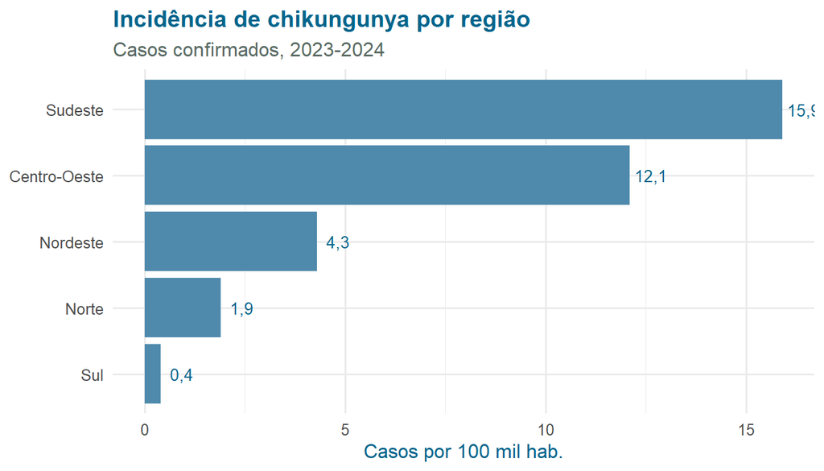

Figura 2: Taxa de incidência de chikungunya confirmada por 100 mil habitantes, por região (2023-2024).

```r
ggplot(tab, aes(x = reorder(regiao, incidencia), y = incidencia)) +
  geom_col(fill = epic95_cores["primaria"]) +
  geom_text(aes(label = format(incidencia, decimal.mark = ",")),
            hjust = -0.15, size = 3.5, color = "#03658c") +
  coord_flip() +
  labs(
    title = "Incidência de chikungunya por região",
    subtitle = "Casos confirmados, 2023-2024",
    x = NULL, y = "Casos por 100 mil hab."
  ) +
  tema_epic95()
```

## 3.4 Distribuição espacial da incidência

A comparação por região responde à pergunta principal, mas achata a variação que existe dentro de cada região. Os dois mapas a seguir descem a esse detalhe. O primeiro pinta cada Unidade da Federação pela taxa de incidência de chikungunya confirmada por 100 mil habitantes; o segundo repete a leitura nos 5.570 municípios, onde os focos aparecem com nitidez. A cor mostra intensidade por habitante, não volume de gente. O denominador é a população residente do Censo 2022 do IBGE.

Os contornos vêm do pacote `geobr`, com os limites oficiais do IBGE. Para o relatório abrir sem depender de download, rode uma vez `recursos/preparar_mapas.R`, que salva as malhas em `recursos/`.

**Casos, população e taxa por UF e por município**

```r
library(here)
library(readr)
library(stringr)

# So desenha os mapas se houver a base espacial (uf e municipio_ibge, que vem do
# 00_preparar_dados.R) e as malhas ja baixadas. A rede de seguranca sintetica nao
# tem essas colunas, entao o relatorio segue rendereizando sem os mapas.
tem_mapa <- all(c("uf", "municipio_ibge") %in% names(chik)) &&
  file.exists(here("recursos", "geo_uf.rds")) &&
  file.exists(here("recursos", "geo_municipios.rds")) &&
  requireNamespace("sf", quietly = TRUE)

if (tem_mapa) {
  library(sf)
  geo_uf  <- readRDS(here("recursos", "geo_uf.rds"))
  geo_mun <- readRDS(here("recursos", "geo_municipios.rds"))

  # Populacao do Censo 2022 (IBGE). O SINAN usa codigo de 6 digitos; o geobr e o
  # arquivo de populacao usam 7. Cortamos o 7o digito para os codigos casarem.
  pop_mun <- read_csv(here("recursos", "populacao_municipios_2022.csv"),
                      show_col_types = FALSE) |>
    mutate(cod6 = str_sub(as.character(cod_ibge7), 1, 6))
  pop_uf <- tibble::tribble(
    ~uf, ~populacao,
    "11",1581196,"12",830018,"13",3941613,"14",636707,"15",8120131,"16",733759,
    "17",1511460,"21",6776699,"22",3271199,"23",8794957,"24",3302729,"25",3974687,
    "26",9058931,"27",3127683,"28",2210004,"29",14141626,"31",20539989,"32",3833712,
    "33",16055174,"35",44411238,"41",11444380,"42",7610361,"43",10882965,"50",2757013,
    "51",3658649,"52",7056495,"53",2817381)

  conf <- chik |>
    filter(classificacao == "Chikungunya confirmada", ano %in% 2023:2024)

  # Faixas de incidencia (estilo boletim): legiveis e robustas a municipios
  # minusculos, onde poucos casos gerariam taxas extremas.
  faixas  <- c(0, 10, 50, 100, 300, Inf)
  rotulos <- c("< 10", "10 a 50", "50 a 100", "100 a 300", "300+")
  cores_faixa <- c("#e6eef3", "#9dc0d2", "#5f97b4", "#03658c", "#02405a")
  em_faixa <- function(x) cut(x, breaks = faixas, labels = rotulos,
                              right = FALSE, include.lowest = TRUE)

  mapa_uf <- geo_uf |>
    mutate(uf = str_pad(as.character(code_state), 2, "left", "0")) |>
    left_join(conf |> mutate(uf = str_pad(as.character(uf), 2, "left", "0")) |>
                count(uf, name = "casos"), by = "uf") |>
    left_join(pop_uf, by = "uf") |>
    mutate(casos = coalesce(casos, 0L), incidencia = casos / populacao * 1e5,
           faixa = em_faixa(incidencia))

  mapa_mun <- geo_mun |>
    mutate(cod6 = str_sub(as.character(code_muni), 1, 6)) |>
    left_join(conf |> mutate(cod6 = str_pad(as.character(municipio_ibge), 6, "left", "0")) |>
                count(cod6, name = "casos"), by = "cod6") |>
    left_join(select(pop_mun, cod6, populacao), by = "cod6") |>
    mutate(casos = coalesce(casos, 0L), incidencia = casos / populacao * 1e5,
           faixa = em_faixa(incidencia))

  tema_mapa <- function() tema_epic95() +
    theme(axis.text = element_blank(), axis.title = element_blank(),
          panel.grid = element_blank())
}
```

**Código**

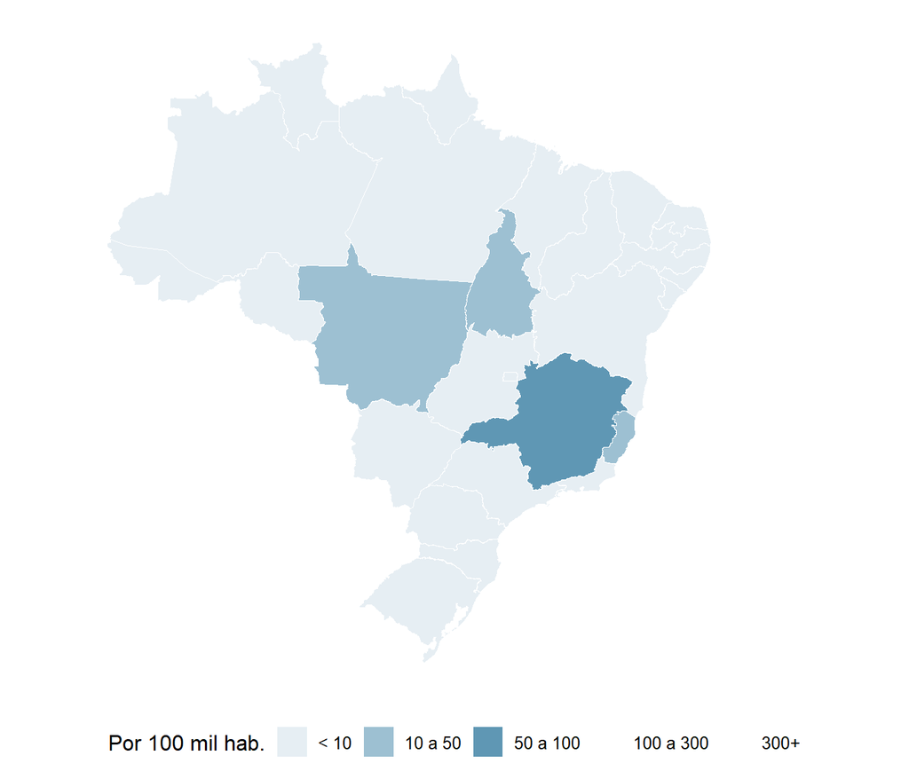

Figura 3: Taxa de incidência de chikungunya confirmada por 100 mil habitantes, por Unidade da Federação (2023-2024).

```r
ggplot(mapa_uf) +
  geom_sf(aes(fill = faixa), color = "white", linewidth = 0.15) +
  scale_fill_manual(values = cores_faixa, drop = FALSE, na.value = "grey85") +
  labs(fill = "Por 100 mil hab.") +
  tema_mapa()
```

**Código**

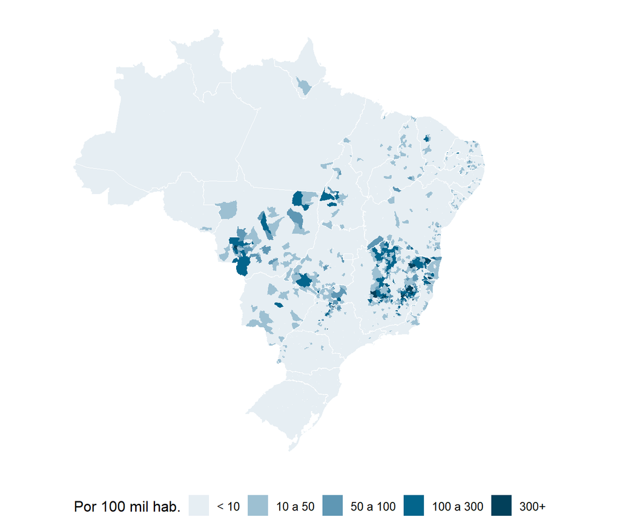

Figura 4: Taxa de incidência de chikungunya confirmada por 100 mil habitantes, por município (2023-2024). As linhas brancas são as divisas estaduais.

```r
ggplot(mapa_mun) +
  geom_sf(aes(fill = faixa), color = NA) +
  geom_sf(data = geo_uf, fill = NA, color = "white", linewidth = 0.2) +
  scale_fill_manual(values = cores_faixa, drop = FALSE, na.value = "grey90") +
  labs(fill = "Por 100 mil hab.") +
  tema_mapa()
```

Os dois mapas contam a mesma história em escalas diferentes. No mapa por UF, a cor separa os estados de maior incidência por habitante daqueles de circulação discreta. O mapa municipal afina o retrato: dentro de um mesmo estado, poucos municípios costumam concentrar a maior parte da carga, enquanto a vizinhança permanece clara. É esse contraste, e não a contagem absoluta, que aponta para onde a vigilância deve olhar primeiro.

## 3.5 Modelo de regressão

O bloco abaixo ajusta a regressão de Poisson. A população entra como *offset*, para o modelo comparar taxas e não contagens brutas. O Nordeste é a referência.

**Regressão de Poisson (razão de taxas por região)**

```r
# Nordeste como categoria de referencia: as demais regioes sao comparadas com ela.
# Usa a tabela regiao-ano, que tem mais de uma linha por regiao (o modelo precisa
# de graus de liberdade; uma linha por regiao deixaria o ajuste saturado).
dados_modelo <- casos_regiao_ano |>
  mutate(regiao = relevel(factor(regiao), ref = "Nordeste"))

# Modelo: casos ~ regiao, com a populacao como offset (log).
# Interpretacao: exp(coef de cada regiao) e a razao de taxas frente ao Nordeste.
mod_pois <- glm(
  casos ~ regiao + offset(log(populacao)),
  family = poisson(link = "log"),
  data = dados_modelo
)

# Razao de taxas (IRR) e intervalo de confianca de 95%
irr <- tibble(
  termo = names(coef(mod_pois)),
  irr   = exp(coef(mod_pois)),
  ic_baixo = exp(confint.default(mod_pois)[, 1]),
  ic_alto  = exp(confint.default(mod_pois)[, 2])
) |>
  filter(termo != "(Intercept)")

irr |>
  gt() |>
  fmt_number(columns = c(irr, ic_baixo, ic_alto), dec_mark = ",", decimals = 3) |>
  cols_label(termo = "Termo", irr = "Razão de taxas",
             ic_baixo = "IC 95% inf.", ic_alto = "IC 95% sup.")
```

| Termo | Razão de taxas | IC 95% inf. | IC 95% sup. |
| --- | --- | --- | --- |
| regiaoCentro-Oeste | 2,813 | 2,653 | 2,983 |
| regiaoNorte | 0,452 | 0,405 | 0,504 |
| regiaoSudeste | 3,696 | 3,542 | 3,857 |
| regiaoSul | 0,096 | 0,080 | 0,115 |

Tomando o Nordeste como referência, a maior razão de taxas foi a da região Sudeste, de 3,70 (IC 95% 3,54 a 3,86). As demais razões de taxas por região, frente ao Nordeste, constam da tabela acima.

## 3.6 Série mensal

O bloco abaixo monta a série mensal de casos por data de notificação. A queda no fim de 2025 é artefato do atraso de notificação, não diminuição real.

**Código**

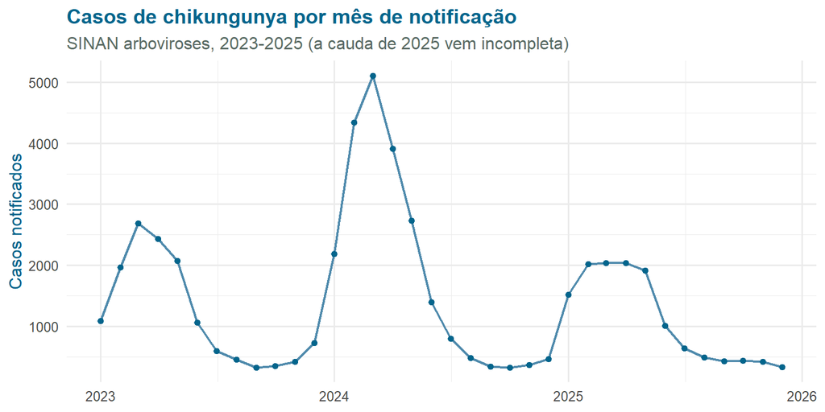

Casos de chikungunya por mês de notificação (2023-2025).

```r
serie <- chik |>
  mutate(mes = floor_date(dt_notificacao, unit = "month")) |>
  count(mes, name = "casos")

ggplot(serie, aes(x = mes, y = casos)) +
  geom_line(color = epic95_cores["primaria"], linewidth = 0.8) +
  geom_point(color = epic95_cores["secundaria"], size = 1.6) +
  labs(
    title = "Casos de chikungunya por mês de notificação",
    subtitle = "SINAN arboviroses, 2023-2025 (a cauda de 2025 vem incompleta)",
    x = NULL, y = "Casos notificados"
  ) +
  tema_epic95()
```

## 3.7 Decomposição da série (STL)

A curva bruta mistura três coisas: a tendência de fundo, a repetição sazonal a cada ano e o que sobra. A decomposição STL (Seasonal-Trend decomposition using Loess) separa esses componentes sem instalar nada além do R base. Ela precisa saber o tamanho do ciclo, doze meses para uma série mensal, e exige ao menos dois ciclos completos, que a série de 2023 a 2025 tem de sobra. Antes de decompor, a série é completada mês a mês, com zero nos meses sem caso, para o ciclo não sair desalinhado.

**Código**

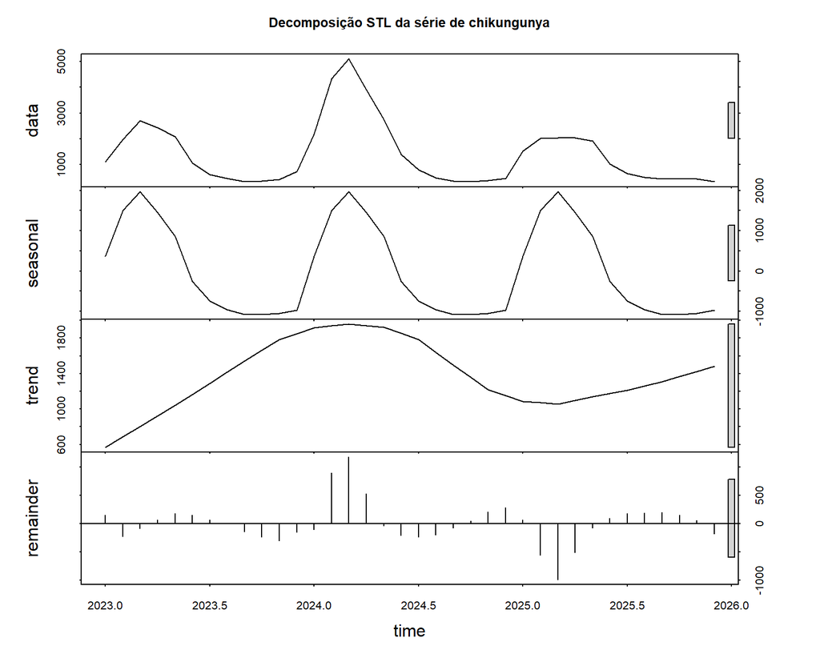

Figura 5: Decomposição STL da série mensal de chikungunya: o dado observado, a sazonalidade, a tendência e o resto.

```r
library(tidyr)

# Grade completa de meses; mes sem caso vira 0, para nao encolher o eixo do tempo.
serie_completa <- tibble(mes = seq(min(serie$mes), max(serie$mes), by = "month")) |>
  left_join(serie, by = "mes") |>
  mutate(casos = replace_na(casos, 0)) |>
  arrange(mes)

serie_ts <- ts(serie_completa$casos, frequency = 12,
               start = c(year(min(serie_completa$mes)), month(min(serie_completa$mes))))

decomp <- stl(serie_ts, s.window = "periodic")
plot(decomp, main = "Decomposição STL da série de chikungunya")
```

A regra prática vale para qualquer série de notificação: nunca leia a ponta como tendência epidemiológica. Antes de afirmar que os casos caíram, pergunte se o período já fechou. É por isso que boletins sérios marcam os últimos meses como dados sujeitos a revisão.

## 3.8 Casos por região e mês

O mapa de calor cruza as duas leituras que interessam à vigilância, o lugar e a sazonalidade, numa figura só. Cada célula é uma região em um mês do calendário, e a cor mostra a intensidade de casos: quanto mais forte, mais casos naquele cruzamento.

**Código**

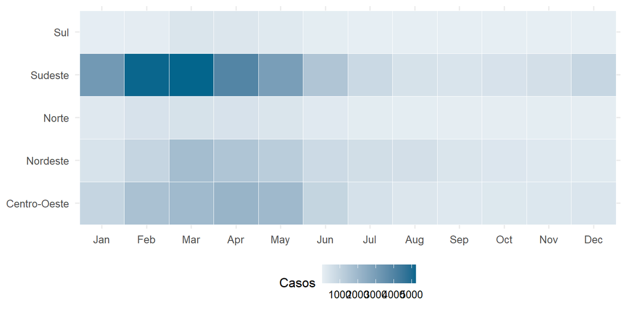

Figura 6: Casos de chikungunya por região e mês do calendário (2023-2025). Cor mais forte indica mais casos.

```r
calor <- chik |>
  mutate(mes_num = month(dt_notificacao)) |>
  count(regiao, mes_num) |>
  mutate(mes_nome = factor(month.abb[mes_num], levels = month.abb))

ggplot(calor, aes(x = mes_nome, y = regiao, fill = n)) +
  geom_tile(color = "white") +
  scale_fill_gradient(low = "#e6eef3", high = epic95_cores[["secundaria"]]) +
  labs(x = NULL, y = NULL, fill = "Casos") +
  tema_epic95()
```

A leitura casa com a série decomposta: os blocos escuros se concentram nos primeiros meses do ano, e não de modo uniforme entre as regiões. Onde a cor carrega, ali a vigilância olha primeiro, tanto no tempo (o mês de maior risco) quanto no lugar (a região que puxa a carga).

# 4 Discussão

O achado principal é a diferença de incidência entre as regiões do país. A região com a maior taxa concentrou o maior peso de casos confirmados por habitante, e o modelo de Poisson traduziu essa diferença em uma razão de taxas frente ao Nordeste. É a comparação entre regiões, e não a contagem absoluta, que aponta onde a circulação do vírus foi mais intensa no período. Essa era a pergunta posta na Introdução.

A análise tem limites que pesam na leitura. Os dados do SINAN estão sujeitos a subnotificação, porque nem todo caso chega ao sistema, e a atraso de notificação, que esvazia os meses mais recentes e explica a queda na cauda de 2025. A classificação final pode mudar após a investigação, e a incidência aqui usa uma população regional ilustrativa, não a estimativa oficial. O modelo é deliberadamente simples: compara apenas regiões, sem ajustar por idade, sexo, tendência temporal ou dependência espacial, e trata as observações como independentes. Razões de taxas dessa forma descrevem a diferença bruta entre regiões, não um efeito causal. Nos mapas, a taxa municipal usa a população do Censo 2022 como denominador e fica instável nos municípios pequenos, onde poucos casos já produzem taxas altas. Por isso a leitura em faixas, e não no valor exato de cada município.

Apesar disso, o fluxo é inteiramente reprodutível e pode ser reexecutado sobre dados atualizados a cada nova extração, o que o torna útil para a vigilância de rotina. Os próximos passos naturais são incorporar a população oficial do IBGE, estender o modelo para ajustar por faixa etária e sazonalidade e corrigir o atraso de notificação antes de interpretar os meses mais recentes.

# 5 Reprodutibilidade e compartilhamento

Este relatório foi produzido em Quarto Markdown com R. Para reproduzi-lo:

1. Clone o repositório e abra o projeto no Positron (arquivo `.Rproj`).
2. Rode `source("bootstrap.R")` no Console para instalar e carregar os pacotes na versão registrada, deixando o ambiente pronto.
3. Rode `R/00_preparar_dados.R` uma vez para baixar do OpenDataSUS e preparar o arquivo `dados/chikungunya_2023_2025.csv` que este relatório lê. O dado que identifica o paciente não é versionado (ver `.gitignore`).
4. Renderize com as três saídas: `quarto render relatorio-chikungunya.qmd`. Para uma saída só, use `--to html`, `--to docx` ou `--to pdf`. O PDF exige LaTeX (`quarto install tinytex`).

# 6 Referências

- Ministério da Saúde. Sistema de Informação de Agravos de Notificação (SINAN). DATASUS. https://datasus.saude.gov.br
- OpenDataSUS. Portal de Dados Abertos do SUS. Arboviroses. https://opendatasus.saude.gov.br
- IBGE. Censo Demográfico 2022: população residente por município. https://sidra.ibge.gov.br (tabela 4714)
- Pereira RHM, Gonçalves CN et al. *geobr: Download Official Spatial Data Sets of Brazil*. IPEA. https://ipeagit.github.io/geobr
- Posit PBC. *Quarto* e *Positron IDE*. https://quarto.org · https://positron.posit.co